# 2019 Bay Wheels Ride Data Exploration and Visualization

### Introduction

Ford GoBike is a regional public bicycle sharing system in the San Francisco Bay Area, California. Beginning operation in August 2013 as Bay Area Bike Share, the Ford GoBike system currently has over 2,600 bicycles in 262 stations across San Francisco, East Bay and San Jose. On June 28, 2017, the system officially launched as Ford GoBike in a partnership with Ford Motor Company.

Ford GoBike, like other bike share systems, consists of a fleet of specially designed, sturdy and durable bikes that are locked into a network of docking stations throughout the city. The bikes can be unlocked from one station and returned to any other station in the system, making them ideal for one-way trips. The bikes are available for use 24 hours/day, 7 days/week, 365 days/year and riders have access to all bikes in the network when they become a member or purchase a pass.

### What is the structure of my dataset?

The FordGoBike data is straightforward and intuitive to understand. This data has been collected efficiently, providing a valuable collection of data to work with and draw conclusions from.

This notebook uses data collected from January 2019 through December, 2019. There were approximatelly 2,500,000 bike rides in the San Francisco Bay area of California, USA documented.

The column header descriptions are as follows (each trip is anonymized):

- Trip Duration (seconds)
- Start Time and Date
- End Time and Date
- Start Station ID
- Start Station Name
- Start Station Latitude
- Start Station Longitude
- End Station ID
- End Station Name
- End Station Latitude
- End Station Longitude
- Bike ID
- User Type (Subscriber or Customer – “Subscriber” = Member or “Customer” = Casual)

In the wrangling process, I decided to add the following columns:

- start_time_month
- end_time_month
- start_time_month_num
- end_time_month_num
- start_time_dayofweek
- start_time_hour
- end_time_hour
- duration_min

### 1.UNIVARIATE VISUALIZATIONS

#### When are most trips taken in terms of time of day, day of the week, or month of the year?

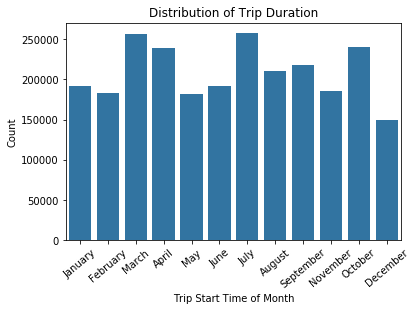

```python
sns.countplot(data = df_clean , x = 'start_time_month', color=base_color)
plt.xlabel('Trip Start Time of Month');
plt.ylabel('Count')
plt.title('Distribution of Trip Duration')
plt.xticks(rotation=40);
```

- It does not seem that any regular trends in a year but it can be seen that winter months are less preferable time in the year.

#### How long does the average trip take?

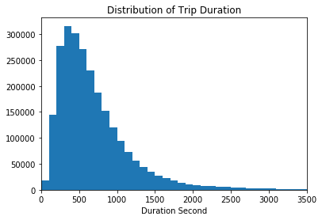

```python
# univariate plot of duration minutes
bin_edges = np.arange(0, df_clean['duration_sec'].max()+100, 100)
plt.hist(data=df_clean, x='duration_sec', bins=bin_edges);
plt.xlim(0, 3500)
plt.title('Distribution of Trip Duration')
plt.xlabel('Duration Second');
```

- It is right screwed with a long tail on the right. It can be seen that generally trips take between 5 and 15 minutes in the graph above.

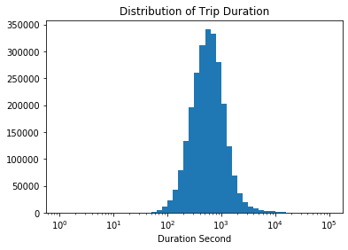

```python
#log scale distribution
bin_edges = 10**np.arange(0, 5+0.1 , 0.1)
ticks = [0.1 , 0.3 , 1 , 3 , 10 , 30 , 100 , 300]
labels = ['{}'.format(v) for v in ticks]

plt.hist(data = df_clean , x = 'duration_sec', bins = bin_edges);
plt.xticks(ticks,labels)
plt.xlabel('Duration Second')
plt.title('Distribution of Trip Duration')
plt.xscale('log');
```

### 2. BIVARIATE VISUALIZATIONS

#### How does the user trends look like in the year?

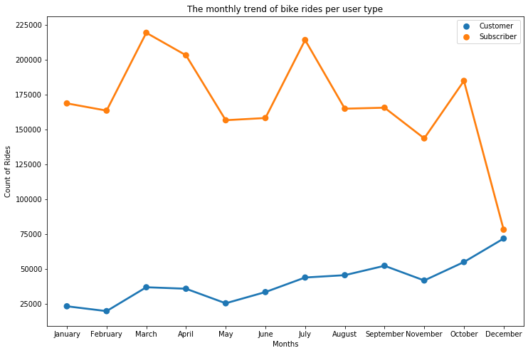

```python
plt.figure(figsize=(12,8))
sns.pointplot(x='start_time_month', y=0, hue='user_type',  data=user_type_count)

plt.title('The monthly trend of bike rides per user type')
plt.xlabel('Months')
plt.ylabel('Count of Rides')
plt.legend();
```

- It can be seen that the customer trend looks increase especially at the end of the year. On the other hand, subscriber trend looks that see the lest level in the year.

#### How does the trip duration distribution between customers and subscribers?

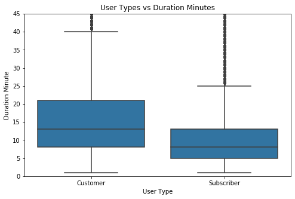

```python
plt.figure(figsize=(8,5))
sns.boxplot(data=df_clean, x='user_type', y='duration_min', color=base_color)
plt.ylim(0, 45)
plt.title('User Types vs Duration Minutes')
plt.xlabel('User Type')
plt.ylabel('Duration Minute');
```

- When we look at the general view, It can be seen that subscribers use bikes for a short time period than customers.

#### User usage distribution in a day

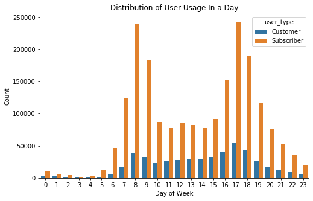

```python
plt.figure(figsize=(8,5))
sns.countplot(data=df_clean, x='start_time_hour', hue='user_type');
plt.title('Distribution of User Usage In a Day')
plt.xlabel('Day of Week')
plt.ylabel('Count');
```

- It has seen that both user usage clearly peaks out on typical rush hours when people go to work in the morning and getting off work in the afternoon and in the evening.

#### User usage distribution in a week

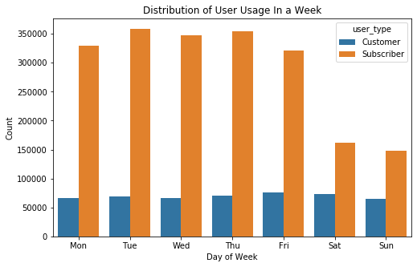

```python
plt.figure(figsize=(8,5))
sns.countplot(data=df_clean, x='start_time_dayofweek', hue='user_type');
plt.xlabel('Day of Week')
plt.title('Distribution of User Usage In a Week')
plt.ylabel('Count');
```

- It has seen that subscriber weekend usage less than weekday usage. This is confirming the usage behavior in the day above. On the other hand, there are not many differences in customer usage between weekends and weekdays.

#### User usage distribution in a year

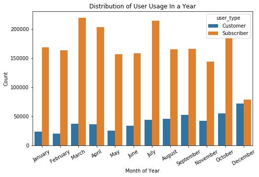

```python
plt.figure(figsize=(8,5))
sns.countplot(data=df_clean, x='start_time_month', hue='user_type');
plt.title('Distribution of User Usage In a Year')
plt.xlabel('Month of Year')
plt.ylabel('Count')
plt.xticks(rotation=30);
```

- It does not seem that any regular trends in a year. Subscriber usage seems that they are the least ride at the end of the year this situation maybe because of the Christmas holiday, they have a holiday and do not have to go to work. On the other hand, customer usage shows that the highest level in December for them.

### Multivariate Visualizations

#### How does the average trip duration change on weekdays between customers and subscribers?

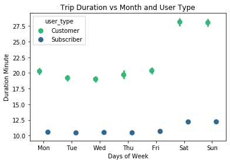

```python
sns.pointplot(data = df_clean, x = 'start_time_dayofweek', y = 'duration_min', hue = 'user_type' , palette = 'viridis_r', dodge = 0.3, linestyles = "")
plt.title('Trip Duration vs Month and User Type')
plt.xlabel('Days of Week')
plt.ylabel('Duration Minute');
```

- It can be seen from the above plot that subscribers ride much shorter/quicker trips compared to customers on each day of the week. Both user types have an obvious increase in trip duration on Saturdays and Sundays over weekends. Subscribers usage seems to maintain a very consistent average duration Monday through Friday.

#### How does the average trip duration change on months between customers and subscribers?

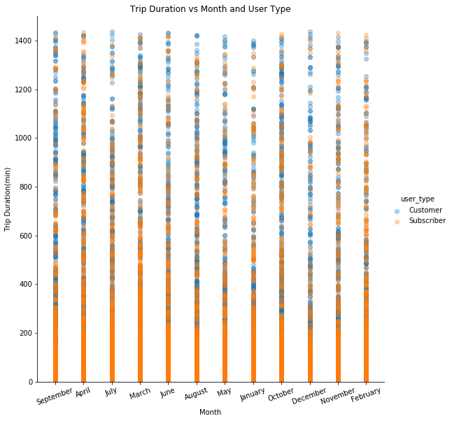

```python
g = sns.FacetGrid(data =  df_clean, hue = 'user_type', height = 8)
g.map(plt.scatter, 'start_time_month','duration_min', alpha = 1/3)
g.add_legend()
plt.ylim(0, 1500)
plt.title('Trip Duration vs Month and User Type')
plt.xlabel('Month')
plt.ylabel('Trip Duration(min)')
plt.xticks(rotation=20);
```

- It can be seen through the plot above, there are customers have more duration than subscribers. The user type does make an impact on trip duration.